# Applied Linear Algebra - Lab 6

Ferdowsi University of Mashhad - Computer Engineering Department

Spring 2022

- Singular Value Decomposition
- Image Compression
- Eigenfaces and Face reconstruction

# SVD

The Singular Value Decomposition (SVD) separates any matrix into simple pieces. it provides a numerically stable matrix decomposition that can be used for a variety of purposes and is guaranteed to exist

In many domains, complex systems will generate data that is naturally arranged in large matrices, or more generally in arrays. For example, a time-series of data from an experiment or a simulation may be arranged in a matrix with each column containing all of the measurements at a given time.

The pixel values in a grayscale image may be stored in a matrix, or these images may be reshaped into large column vectors in a matrix to represent the frames of a movie. Remarkably, the data generated by these systems are typically low rank, meaning that there are a few dominant patterns that explain the high-dimensional data. The SVD is a numerically robust and efficient method of extracting these patterns from data.

Generally, we are interested in analyzing a large data set $X_{n \times m}$:

$$ X = \begin{bmatrix} \mid & \mid & & \mid \\ {\bf x}_{1} & {\bf x}_{2} & \cdots & {\bf x}_{m}\\ \mid & \mid & & \mid \\ \end{bmatrix} $$

The columns $x_k \in C_n$ may be measurements from simulations or experiments. For example, columns may represent images that have been reshaped into column vectors with as many elements as pixels in the image.

The SVD is a unique matrix decomposition that exists for every matrix $X_{n \times m}$:

$$ \bf X = \bf U \times \Sigma \times \bf V^\intercal $$

where $ \bf U_{n \times n}$ is a matrix containing unit eigenvectors of $X X^\intercal$ and $\bf V_{m \times m}$ is containing unit eigenvectors of $X^\intercal X$.

$ \bf \Sigma$ is a diagonal matrix containing square roots of the equal eigenvalues of $ X X^\intercal$ and $X^\intercal X$ (Singular Values $\sigma$.)

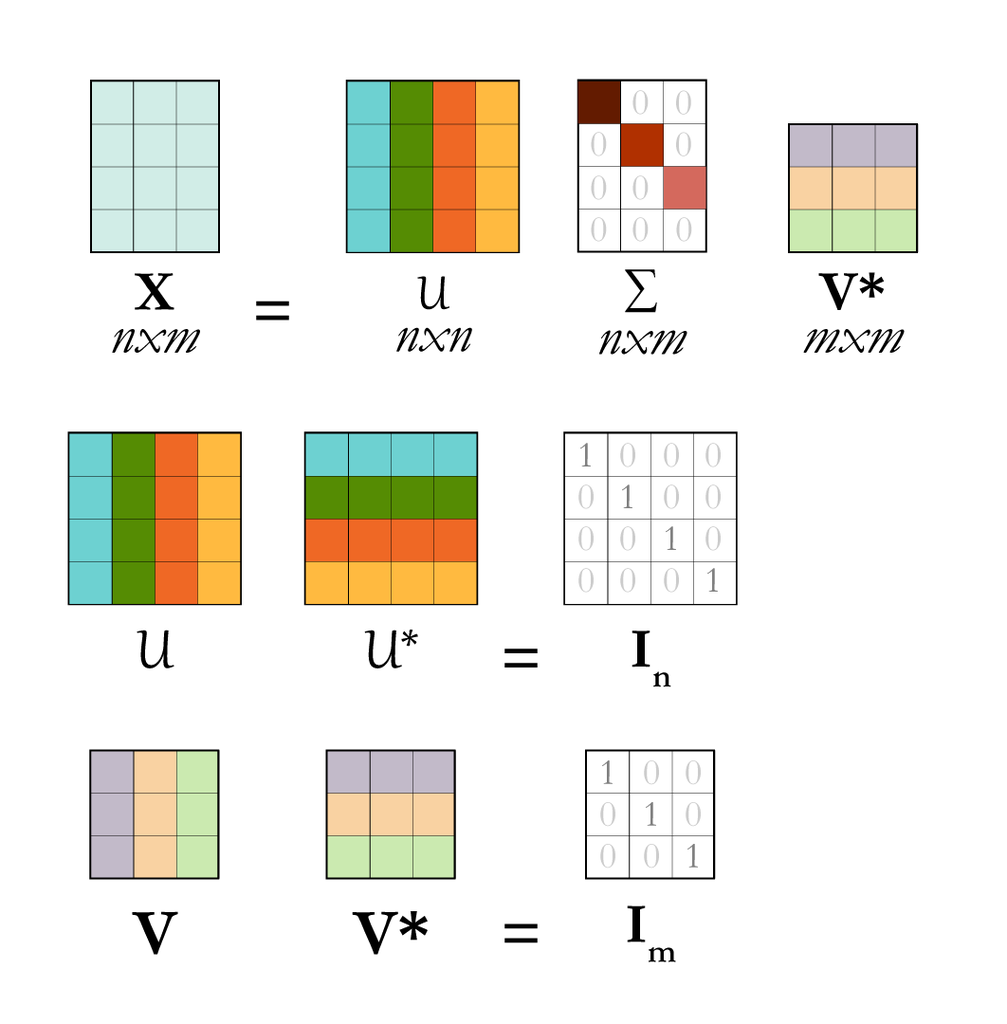

```python
import numpy as np
from matplotlib.image import imread
import matplotlib.pyplot as plt
import sys, os
import scipy
```

## Exercise 1

Define function `svd` which takes matrix $ \bf X_{n \times m}$ and applies SVD decomposition then returns $ \bf U_{n \times n} , \bf \Sigma_{n \times m}, \bf V^\intercal_{m \times m} $

```python
from numpy.linalg import eig
from numpy import argsort
from numpy import diag

def svd(X):
    # compute X.T * X
    xtx = X.T @ X # SOLUTION

    # calculate eigenvalues and eigenvectors of XTX
    # use linalg.eig() function, it returns eigenvalues and normalized (unit length) eigenvectors,
    # such that the column v[:,i]
    # is the eigenvector corresponding to the eigenvalue eigen_vals[i]
    eig_vals, V = eig(xtx) # SOLUTION

    # singular values of X are the square root of the non-negative eigenvalues of XtX or XXt
    singular_vals = np.sqrt(eig_vals) # SOLUTION

    # sort both sigular values and matrix V in descending order so that the higher values are placed before the lower ones.
    # use np.argsort(), it returns the indices that would sort an array, use the indcies to sort V based on singular values order
    sort_indices = argsort(singular_vals) # SOLUTION
    sort_indices = sort_indices[::-1] #descending
    singular_vals = singular_vals[sort_indices] # SOLUTION
    V = V[:, sort_indices] # SOLUTION

    # U is matrix of eigenvectors of XXT
    # for every eigenvector of XXT (Ui):
    # Ui = (X @ Vi / singularValue(i))
    U = X @ V / singular_vals # SOLUION

    # sigma matrix is a diagonal matirx with singular values of X in its diagonal
    # singluar_vals is an array of singular values of X, we can use np.diag() to make sigma matrix using singular_vals
    sigma = diag(singular_vals) # SOLUTION

    return U.real, sigma.real, V.T.real
```

```python
xx = np.random.random((5, 5))
print(xx)
ux, sx, vx = svd(xx)
```

```
[[0.32929937 0.82348302 0.3152817  0.41994447 0.95378909]
 [0.85823822 0.16965374 0.77649758 0.78344783 0.29003635]
 [0.80520895 0.64040098 0.84480452 0.53341061 0.85625696]
 [0.20437116 0.20161454 0.74894389 0.91104657 0.19012398]
 [0.36576789 0.34573788 0.1134189  0.87027688 0.22097939]]
```

```python
print(ux @ sx @ vx)
```

```
[[0.32929937 0.82348302 0.3152817  0.41994447 0.95378909]
 [0.85823822 0.16965374 0.77649758 0.78344783 0.29003635]
 [0.80520895 0.64040098 0.84480452 0.53341061 0.85625696]
 [0.20437116 0.20161454 0.74894389 0.91104657 0.19012398]
 [0.36576789 0.34573788 0.1134189  0.87027688 0.22097939]]
```

# Image Compression

Images are represented in a rectangular array where each element corresponds to the grayscale value for that pixel. For colored images we have a 3-dimensional array of size n×m×3, where n and m represent the number of pixels vertically and horizontally, respectively, and for each pixel we store the intensity for colors red, green and blue. What we are going to do is to repeat the low-rank approximation procedure that we was introduced in the lectures on a larger matrix, that is, we create the low-rank approximation of a matrix that represents an image for each color separately. The resulting 3-dimensional array will be a good approximation of the original image. Let’s say that you have a grayscale image that is 100 × 100 pixels in dimension. Each of those pixels can be represented in a matrix that is also 100 × 100, where the values in the matrix range from 0 to 255 (or from 0.0 to 1.0. These values represent intensity).

Now, if you wanted to store that image, you would have to keep track of exactly 100 × 100 numbers or 10,000 different pixel values. That may not seem like a lot, but you can also think if the image as your desktop background which is probably and image 1920 × 1200 in which you would have to store 2,304,000 different pixel values! And that’s if it was a grayscale image, if it was colored, it would be triple that, having to keep track of 6,912,000 different numbers, which if you think about one of those numbers equating to a byte on your computer, that equals 2.3MB for a grayscale image or 6.9MB for a colored image. Just imagine how quickly a movie would increase in size if it was updating at the rate of 30-60 frames per second. What we can actually do to save memory on our image is to compute the SVD and then calculate some level of precision. You would find that in an image that is 100 × 100 pixels would look really quite good with only 10 modes of precision using the SVD computation. The reason why the SVD is computed is because you can use the first components of these matrices to give you a close approximation of what the actual matrix looked like.

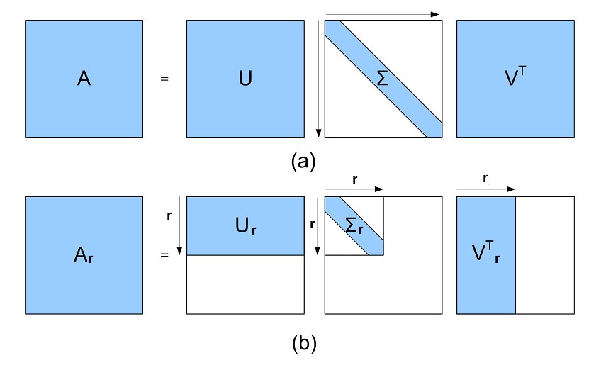

## Exercise 2

Let's implement this procedure.

```
image dimensions: (667, 1000, 3)
grayscale image dimensions: (667, 1000)
```

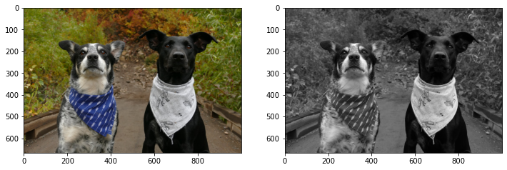

```python
img = imread('dogs.jpeg')
img = img.astype(float) / np.iinfo(img.dtype).max

img_grayscale = np.mean(img, -1)

n, m = img_grayscale.shape


plt.figure(0, (12,6))
plt.subplot(1, 2, 1)
plt.imshow(img)
plt.subplot(1, 2, 2)
plt.imshow(img_grayscale, cmap='gray')
print(f'image dimensions: {img.shape}')
print(f'grayscale image dimensions: {img_grayscale.shape}')
```

```python
# Suppose the basic unit of space is an element of a matrix. For example a 2 x 3 matrix requires 6 unit of space.
def storage_reduction(r, n, m):
    # Original matrix is n x m
    original = n * m

    # U: n * r
    # For S we only need to hold the r singular values. We can always reconstruct the diagonal matrix S from the singlar values.
    # S: r
    # VT: r * m
    compressed = n * r + r + r * m
    return 100 - (compressed / original) * 100
```

Calculate the singular value decomposition of the grayscale image.

```python
U, S, VT = svd(img_grayscale) # SOLUTION

print(f'U: {U.shape},   S: {S.shape},   VT: {VT.shape}')
```

```
U: (667, 1000),   S: (1000, 1000),   VT: (1000, 1000)
```

Approximate the grayscale image using only the first `r` singular values.

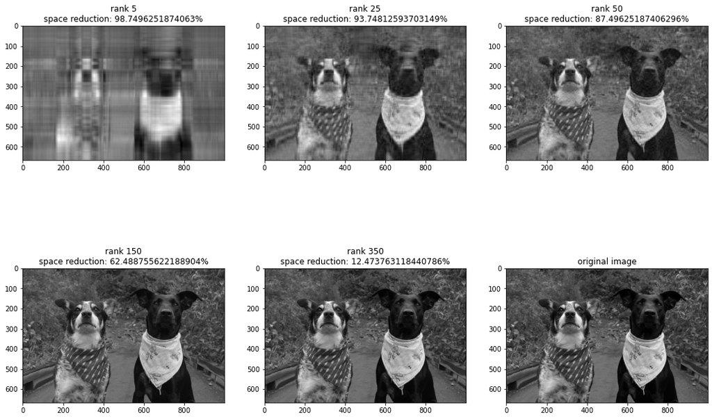

```python
ranks = [5, 25, 50, 150, 350]

plt.figure(0, (18, 12))
for idx, r in enumerate(ranks):

    U_r = U[:, :r] # SOLUTION
    S_r = S[:r, :r] # SOLUTION
    VT_r = VT[:r, :] # SOLUTION

    A_r = U_r @ S_r @ VT_r # SOLUTION

    plt.subplot(2,3, idx+1)
    plt.imshow(A_r, cmap='gray')
    plt.title(f'''rank {r}\nspace reduction: {storage_reduction(r, n, m)}%''')

plt.subplot(2, 3, idx+2)
plt.imshow(img_grayscale, cmap='gray')
plt.title('original image')
```

Find a value of `r` that results in approximately 70% reduction in space.

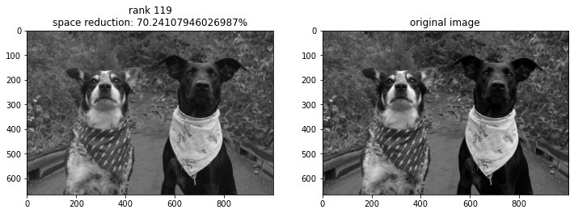

```python
r = 119 # SOLUTION
U_r = U[:, :r] # SOLUTION
S_r = S[:r, :r] # SOLUTION
VT_r = VT[:r, :] # SOLUTION

A_r = U_r @ S_r @ VT_r # SOLUTION

plt.figure(0, (12,6))
plt.subplot(1, 2, 1)
plt.imshow(A_r, cmap='gray')
plt.title(f'''rank {r}\nspace reduction: {storage_reduction(r, n, m)}%''')
plt.subplot(1, 2, 2)
plt.imshow(img_grayscale, cmap='gray')
plt.title('original image')
```

Find a value of `r` that results in approximately 50% reduction in space.

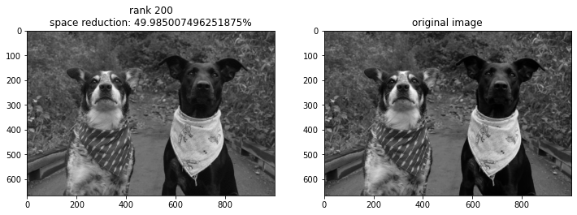

```python
r = 200 # SOLUTION
U_r = U[:, :r] # SOLUTION
S_r = S[:r, :r] # SOLUTION
VT_r = VT[:r, :] # SOLUTION

A_r = U_r @ S_r @ VT_r # SOLUTION

plt.figure(0, (12,6))
plt.subplot(1, 2, 1)
plt.imshow(A_r, cmap='gray')
plt.title(f'''rank {r}\nspace reduction: {storage_reduction(r, n, m)}%''')
plt.subplot(1, 2, 2)
plt.imshow(img_grayscale, cmap='gray')
plt.title('original image')
```

Approximate the colored image using only the first `r` singular values.

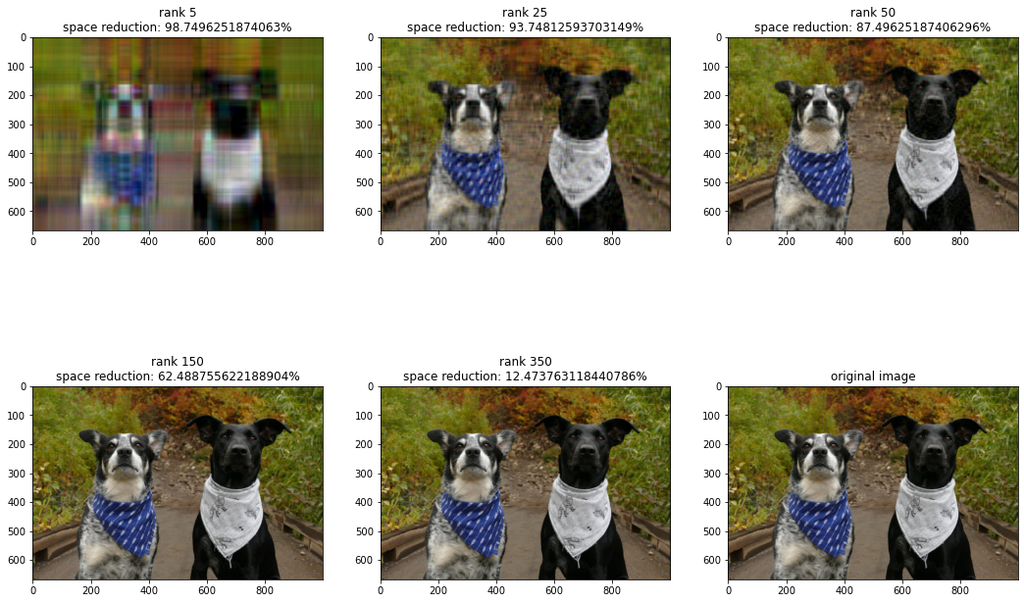

```python
ranks = [5, 25, 50, 150, 350]

img_red, img_green, img_blue =  img[:, :, 0], img[:, :, 1], img[:, :, 2]

U_R, S_R, VT_R = svd(img_red)
U_G, S_G, VT_G = svd(img_green)
U_B, S_B, VT_B = svd(img_blue)


plt.figure(0, (18, 12))
for idx, r in enumerate(ranks):

    # Red
    U_R_r = U_R[:, :r] # SOLUTION
    S_R_r = S_R[:r, :r] # SOLUTION
    VT_R_r = VT_R[:r, :] # SOLUTION
    A_R_r = U_R_r @ S_R_r @ VT_R_r # SOLUTION

    # Green
    U_G_r = U_G[:, :r] # SOLUTION
    S_G_r = S_G[:r, :r] # SOLUTION
    VT_G_r = VT_G[:r, :] # SOLUTION
    A_G_r = U_G_r @ S_G_r @ VT_G_r # SOLUTION

    # Blue
    U_B_r = U_B[:, :r] # SOLUTION
    S_B_r = S_B[:r, :r] # SOLUTION
    VT_B_r = VT_B[:r, :] # SOLUTION
    A_B_r = U_B_r @ S_B_r @ VT_B_r # SOLUTION

    # Stack 'em together!
    A_r = np.dstack((A_R_r, A_G_r, A_B_r))

    plt.subplot(2,3, idx+1)
    plt.imshow(np.clip(A_r, 0, 1), cmap='gray')
    plt.title(f'''rank {r}\nspace reduction: {storage_reduction(r, n, m)}%''')

plt.subplot(2, 3, idx+2)
plt.imshow(img, cmap='gray')
plt.title('original image')
```

# Eigenfaces and Face reconstruction

One of the most striking demonstrations of SVD/PCA is the so-called eigenfaces example. In this problem, SVD on mean-subtracted data is applied to a large library of facial images to extract the most dominant correlations between images. The result of this decomposition is a set of eigenfaces that define a new coordinate system. Images may be represented in these coordinates by taking the dot product with each of the principal components.

To implement SVD-based face recognition we have chosen the "Labeled Faces in the Wild" Database. This database consists of more than 13000 centered labeled face images of more than 5 thousands famous people, so we are able to pick several distinct photos for each person to reconstruct a new face with them. Fortunately, the dataset is obtainable from datasets module of sklearn where you can specify the minimum number of face images per person. We chose this parameter as 20 and loaded 1932 different pictures of 28 people. Every image from dataset consists of 62 x 47 pixels.

```python
from sklearn.datasets import fetch_lfw_people

lfw_dataset = fetch_lfw_people(min_faces_per_person=20)
# height and width of each image
_, h, w = lfw_dataset.images.shape
X = lfw_dataset.images
y = lfw_dataset.target
target_names = lfw_dataset.target_names
```

```python
def plot_faces(images, h, w, rows=3, cols=4, no_padding = False):
    plt.figure(figsize=(16,8))

    for i in range(rows * cols):
        if no_padding:
            plt.tight_layout(pad=0.00)

        plt.subplot(rows, cols, i + 1)
        plt.imshow(images[i], cmap=plt.cm.gray)
        plt.xticks(())
        plt.yticks(())
```

We split some faces (unseen faces) and use rest of images (train_X) to build the eigenfaces. later on we use the eigenfaces to reconstruct the unseen faces.

```python
unseen_face0 = X[y==0]
unseen_face1 = X[y==1]
train_X = X[y>1]
```

lets visualise some of the faces:

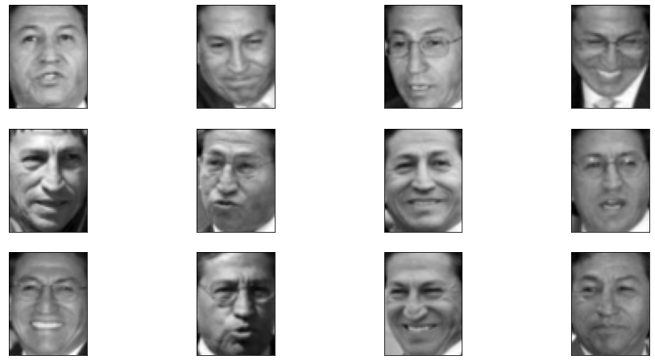

```python
# person in unseen face0:
plot_faces(unseen_face0, h, w)
```

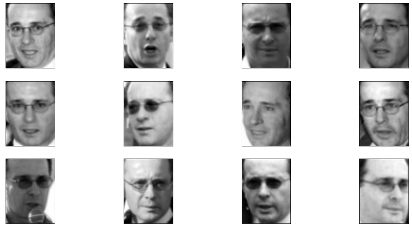

```python
# person in unseen face1:
plot_faces(unseen_face1, h, w)
```

```
(None, (1932, 62, 47))
```

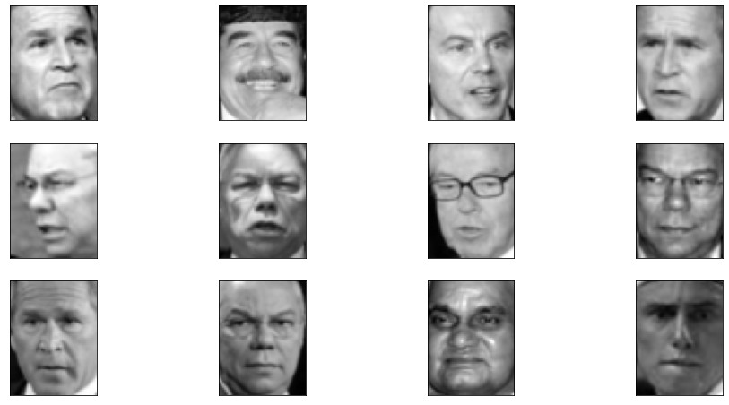

```python
plot_faces(X, h, w), X.shape
```

# Making the eigenfaces

## Exercise 3

### Average face

Let N denote the total number of images in the `train_X` dataset (N = 1858). Additionally, let `h` and `w` represent the row and column dimension of a given image matrix, respectively.

Let an image be denoted by $I \in R^{h \times w}$ where: $$ I = \begin{bmatrix} \mid & \mid & & \mid \\ {\bf i}_{1} & {\bf i}_{2} & \cdots & {\bf i}_{w}\\ \mid & \mid & & \mid \\ \end{bmatrix} $$

**The Average Image:** The first step is to acquire an average image of all images in dataset. This average will be used for later computation in the algorithm.

$$ avgFace = \frac{1}{N} \sum_{j=1}^{N} I_{j} $$

**Question1: build a function to get the avergae image of a given dataset:**

```python
# avgFace
def get_mean_face(train_X):
    sum_face = np.zeros((h, w))
    for i in range(train_X.shape[0]):
        sum_face += train_X[i] # SOL
    avgFace = sum_face / train_X.shape[0] # SOL
    return avgFace
```

Now Lets visualise the average face:

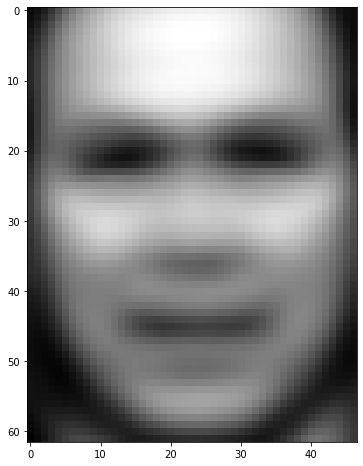

```python
avgFace = get_mean_face(train_X)
plt.figure(figsize=(16,8))
plt.imshow(avgFace, cmap=plt.cm.gray)
```

**Question2:** Next, subtract `avgFace` from each image in `train_X`:

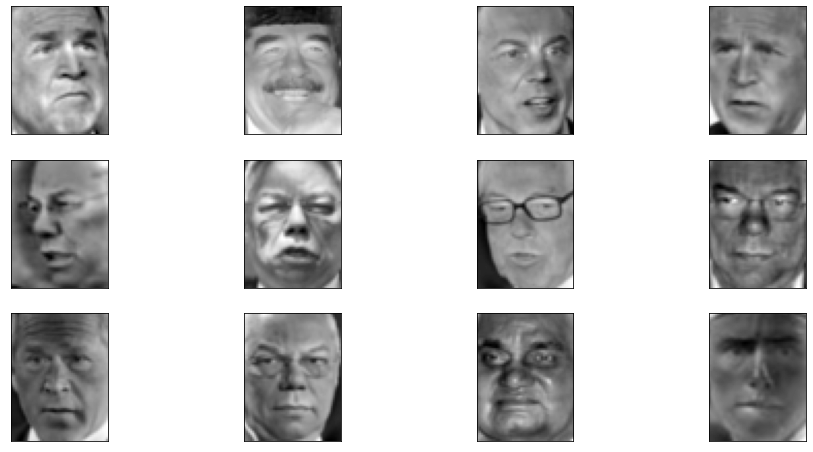

```python
# subtract avgFace from each image and put the result in train_X_ms (train_X mean subtracted)
train_X_ms = train_X -  avgFace # SOL
plot_faces(train_X_ms, h, w)
```

## Building the data matrix

Now we have to reshape each image into a large column vector with 62 $\times$ 47 elements and stack them horizontally as columns in the data matrix $\text{data_matrix}_{(h \times w) \times N}$:

[figure not shown]

The result is mean-subtracted images in one big matrix `data_matrix`.

**Question 3:** build a function that returns the `data_matrix` (described above) for the given array of images:

```python
def faces_to_matrix(faces):
    result = np.vstack([faces[i].flatten() for i in range(faces.shape[0])]).T # SOL
    return result

data_matrix = faces_to_matrix(train_X_ms)
data_matrix.shape
```

```
(2914, 1858)
```

# SVD

SVD is a method used frequently in situations where data to be manipulated is large and complex yet only certain components or behavior need to be known to carry out the process in question. An interesting note about some of the functionality of SVD, the values that the singular value decomposition of a given matrix are made up of are actually providing useful information about patterns and structures that were found in the original matrix. Lets take the svd of the mean-subtracted `data_matrix`:

$$ \text{data_matrix} = U \times Sigma \times VT $$

**Question 4:** take the svd of data_matrix:

```python
U, Sigma, VT = svd(data_matrix) # SOL
```

The columns of U are called eigenfaces, they provide an orthonormal basis for the `data_matrix` (to which SVD was performed), and are providing some of the principal components of that matrix. SVD is useful in this way as it relies on the fact that the data being manipulated is not truly random; there are natural patterns and common structures lying within the data.

The eigenfaces (columns of U) can be reshaped back to 62 * 47 images.

**Question 5** build a function that returns a list of the reshaped version of eigenfaces, starting from `start_index` to `end_index`:

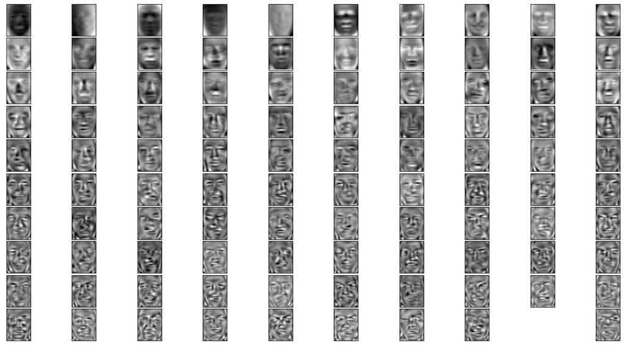

```python
# reshape columns of matrix U, strarting from start_index to end_index, to the original h*w shape
def reshape_image_from_matrix(matrix, start_index, end_index, h, w):
    result = []
    for i in range(start_index, end_index):
        reshaped_eigenface = matrix[:, i].reshape((h, w)) # SOL
        result.append(reshaped_eigenface)
    return result

eigenfaces = reshape_image_from_matrix(U, 0, 100, h, w)
# fitst 100 eigen faces
plot_faces(eigenfaces, h, w, rows=10, cols = 10, no_padding=True)
```

In this case, see that the left singular vectors are preserving the overall structure of the faces in the database as principal components. It is also worth noting that primary singular vectors (i.e. u1, u2, u3, etc.) will preserve this structure much better than that of the latter vectors (um−1, um) due to the accumulation of skewing features from the database as it transcends through the images. These primary vectors provide very good low-dimensional representations of the matrix which has been decomposed by this process.

# Reconstrut the unseen faces:

Using the eigenface library, U, obtained above, we now attempt to approximately represent an image that was not in the training data (the unseen faces). At the beginning, we held back two individuals (unseen_face0, unseen_face1), and we now use one of their images as a test image, `testFace`. We will see how well a rank-r SVD basis will reconstruct this image using the following projection:

$$ \text{testFace_ms} = testFace - avgFace \\ \text{testFace_reconstructed} = avgFace + \hat{U} \times \hat{U}^T \times \text{testFace_ms} $$

where $\hat{U}$ is the rank-r approximation of eigenfaces. (first `r` columns of matrix `U`)

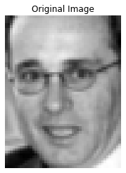

```python
testFace = unseen_face1[0]
plt.imshow(testFace)
plt.set_cmap('gray')
plt.title('Original Image')
plt.axis('off')
plt.show()
```

as we mentioned before: $$ \text{testFace_ms} = testFace - avgFace \\ \text{testFace_reconstructed} = avgFace + \hat{U} \times \hat{U}^T \times \text{testFace_ms} $$

**Question:** build a function that reconstructs the input image based on the approximation of eigenfaces in matrix U:

- `testFace` is in $ h \times w $ dimension, but eigenfaces are in $ D $ dimension (D = h * w). so we need to flatten testFace into a thin column vector in $ D $ dimension.
- same goes for `avgFace`, we need to reshape it into a (h*w, 1) vector.
- build `U_hat` based on the given `r` and `U`. (`U_hat` is the first `r` eigenfaces in `U`).
- subtract avgFace from testFace
- calculate `testFace_reconstructed` based on the projection we mentioned above.
- reshape the result back to the original image dimension ($h \times w$).

```python
def reconstruct(testFace, avgFace, U, r, h, w):
    testFace_reshaped = testFace.flatten() # SOL
    avgFace_reshaped = avgFace.flatten() # SOL
    U_hat = U[:, :r] # SOL
    testFace_mean_sub = testFace_reshaped - avgFace_reshaped # SOL
    testFace_reconstructed = avgFace_reshaped + U_hat @ (U_hat.T @ testFace_mean_sub) # SOL

    reshaped_result = testFace_reconstructed.reshape((h, w))  # SOL
    return reshaped_result
```

**Q:** reconstruct the `testFace` with r = 25 using the `reconstruct()` function.

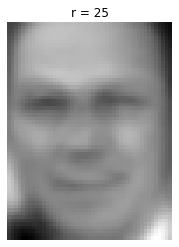

```python
r = 25
testFace = unseen_face1[0]
recon_testFace = reconstruct(unseen_face1[0], avgFace, U, r, h, w)  # SOL

plt.imshow(recon_testFace)
plt.set_cmap('gray')
plt.title('r = {}'.format(r))
plt.axis('off')
plt.show()
```

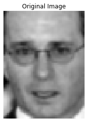

```python
testFace = unseen_face1[4]
plt.imshow(testFace)
plt.set_cmap('gray')
plt.title('Original Image')
plt.axis('off')
plt.show()
```

**Q:** now lets use the eigenface approximation for various values of `r`.

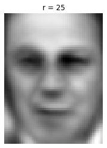

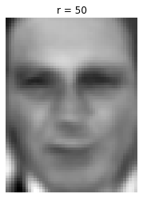

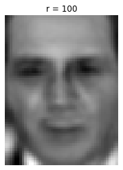

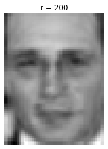

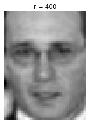

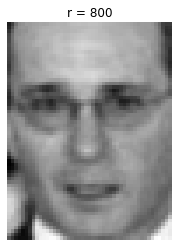

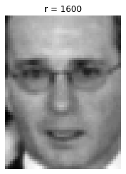

```python
r_list = [25, 50, 100, 200, 400, 800, 1600]

for r in r_list:
    reconFace = reconstruct(testFace, avgFace, U, r, h, w) # SOL
    img = plt.imshow(reconFace)
    img.set_cmap('gray')
    plt.title('r = {}'.format(r))
    plt.axis('off')
    plt.show()
```

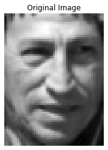

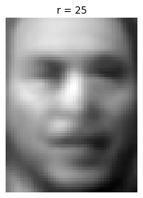

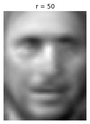

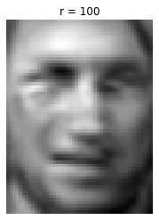

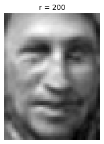

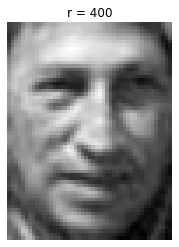

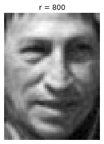

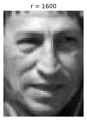

```python
testFace = unseen_face0[4]
plt.imshow(testFace)
plt.set_cmap('gray')
plt.title('Original Image')
plt.axis('off')
plt.show()

r_list = [25, 50, 100, 200, 400, 800, 1600]

for r in r_list:
    reconFace = reconstruct(testFace, avgFace, U, r, h, w) # SOL
    img = plt.imshow(reconFace)
    img.set_cmap('gray')
    plt.title('r = {}'.format(r))
    plt.axis('off')
    plt.show()
```

> This document was compiled, gathered and coded by the teaching assistant team and may be used only for educational purposes. The authors would like to thank the many projects and educational material that made their source code freely available on the internet, especially otter-grader that made the generation and sanitization of the notebook easier.